# Prediction Assignment Writeup

Mohammed Abd El-Ra’ouf

June 29, 2017

## Background

Using devices such as Jawbone Up, Nike FuelBand, and Fitbit it is now possible to collect a large amount of data about personal activity relatively inexpensively. These type of devices are part of the quantified self movement – a group of enthusiasts who take measurements about themselves regularly to improve their health, to find patterns in their behavior, or because they are tech geeks. One thing that people regularly do is quantify how much of a particular activity they do, but they rarely quantify how well they do it. In this project, your goal will be to use data from accelerometers on the belt, forearm, arm, and dumbell of 6 participants. They were asked to perform barbell lifts correctly and incorrectly in 5 different ways. More information is available from the website here: http://groupware.les.inf.puc-rio.br/har (see the section on the Weight Lifting Exercise Dataset).

## Data Loading and Exploratory Analysis

# Preparation

Load the required Packages

```r
required.packages <- c("knitr", "caret", "rpart", "rpart.plot", "rattle", "randomForest", "corrplot")
 sapply(required.packages, library, character.only = T)
```

[output not shown]

Download and Load data-sets.

```r
setwd("~/R/Data/Data Science Specialization/08 - Practical Machine Learning/Peer Assignment/")
Training.URL <- "https://d396qusza40orc.cloudfront.net/predmachlearn/pml-training.csv"
Test.URL <- "https://d396qusza40orc.cloudfront.net/predmachlearn/pml-testing.csv"
Training.Set <- "pml-training.csv"
Test.Set <- "pml-testing.csv"

if(!file.exists(Training.Set))
  {
  download.file(Training.URL, Training.Set, method = "wget")
  }
training <- read.csv(Training.Set)

if(!file.exists(Test.Set))
  {
  download.file(Test.URL, Test.Set, method = "wget")
  }
testing  <- read.csv(Test.Set)
```

Create a partition with the training dataset

```r
set.seed(2468)
inTrain  <- createDataPartition(training$classe, p=0.7, list=FALSE)
Train.partition <- training[inTrain, ]
Test.partition  <- training[-inTrain, ]
```

```r
dim(Train.partition)
```

```
## [1] 13737   160
```

```r
dim(Test.partition)
```

```
## [1] 5885  160
```

# Cleaning the Data

Both datasets have 160 variables. Those variables have plenty of NA, Near Zero variance (NZV) variables and ID variables that can be removed

```r
# remove variables with Nearly Zero Variance
NZV <- nearZeroVar(Train.partition)
Train.partition <- Train.partition[, -NZV]
Test.partition  <- Test.partition[, -NZV]
```

```r
# remove variables that are mostly NA
NA.removal  <- sapply(Train.partition, function(x) mean(is.na(x))) > 0.95
Train.partition <- Train.partition[, NA.removal==FALSE]
Test.partition  <- Test.partition[, NA.removal==FALSE]
```

```r
# remove identification only variables (columns 1 to 5)
Train.partition <- Train.partition[, -(1:5)]
Test.partition  <- Test.partition[, -(1:5)]
```

```r
dim(Train.partition)
```

```
## [1] 13737    54
```

```r
dim(Test.partition)
```

```
## [1] 5885   54
```

After cleaning the data the variables reduced to 54 var. 53 will used to build the models, and the last one “No. 54” is the outcome.

## Correlation Analysis

A correlation among variables is analysed before proceeding to the modeling procedures.

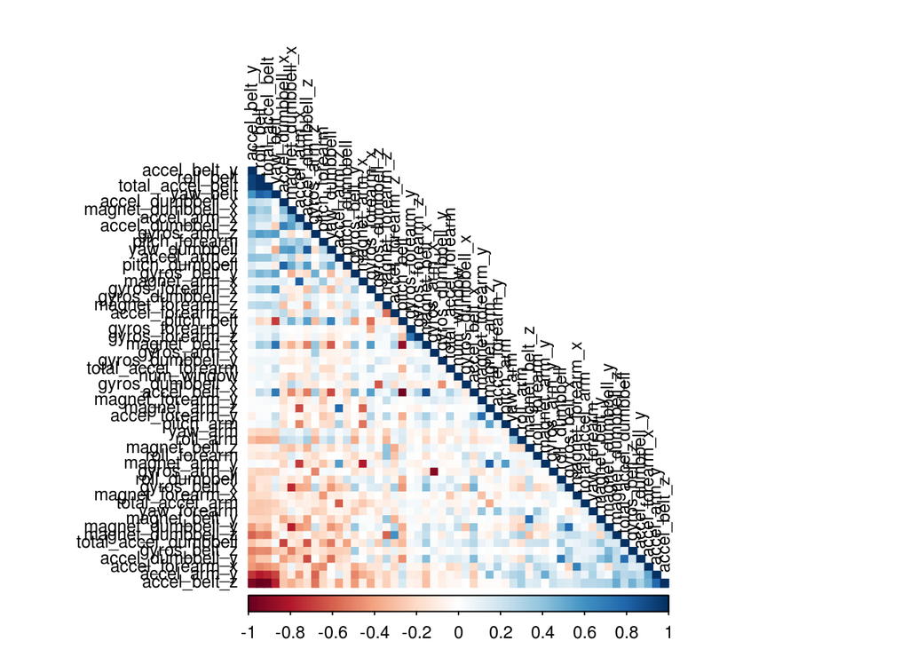

```r
corMatrix <- cor(Train.partition[, -54])
corrplot(corMatrix, order = "FPC", method = "color", type = "lower",
         tl.cex = 0.8, tl.col = rgb(0, 0, 0))
```

## Building Prediction Model

# Cross Validation “Random Forest”

Creating the Model

```r
set.seed(2468)
crossVaildMod = trainControl(method="cv",number=3,allowParallel=T,verboseIter=T)
RandomForestModel = train(classe~., data=Train.partition, method="rf",trControl= crossVaildMod)
RandomForestModel$finalModel
```

```
##
## Call:
##  randomForest(x = x, y = y, mtry = param$mtry)
##                Type of random forest: classification
##                      Number of trees: 500
## No. of variables tried at each split: 27
##
##         OOB estimate of  error rate: 0.2%
## Confusion matrix:
##      A    B    C    D    E class.error
## A 3906    0    0    0    0 0.000000000
## B    6 2648    3    1    0 0.003762227
## C    0    5 2391    0    0 0.002086811
## D    0    0    9 2242    1 0.004440497
## E    0    1    0    2 2522 0.001188119
```

Predecting using the prevuies model

```r
predictRandomForest <- predict(RandomForestModel, newdata=Test.partition)
confMatRandomForest <- confusionMatrix(predictRandomForest, Test.partition$classe)
confMatRandomForest
```

```
## Confusion Matrix and Statistics
##
##           Reference
## Prediction    A    B    C    D    E
##          A 1672    2    0    0    0
##          B    1 1136    2    0    0
##          C    0    1 1024    7    0
##          D    0    0    0  957    0
##          E    1    0    0    0 1082
##
## Overall Statistics
##
##                Accuracy : 0.9976
##                  95% CI : (0.996, 0.9987)
##     No Information Rate : 0.2845
##     P-Value [Acc > NIR] : < 2.2e-16
##
##                   Kappa : 0.997
##  Mcnemar's Test P-Value : NA
##
## Statistics by Class:
##
##                      Class: A Class: B Class: C Class: D Class: E
## Sensitivity            0.9988   0.9974   0.9981   0.9927   1.0000
## Specificity            0.9995   0.9994   0.9984   1.0000   0.9998
## Pos Pred Value         0.9988   0.9974   0.9922   1.0000   0.9991
## Neg Pred Value         0.9995   0.9994   0.9996   0.9986   1.0000
## Prevalence             0.2845   0.1935   0.1743   0.1638   0.1839
## Detection Rate         0.2841   0.1930   0.1740   0.1626   0.1839
## Detection Prevalence   0.2845   0.1935   0.1754   0.1626   0.1840
## Balanced Accuracy      0.9992   0.9984   0.9982   0.9964   0.9999
```

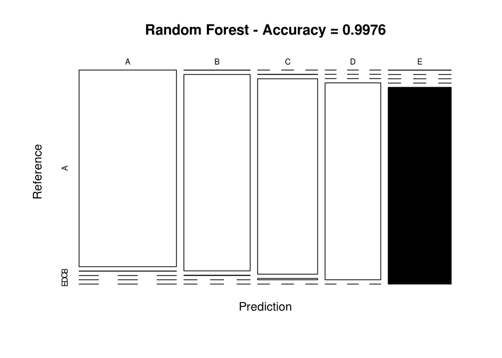

```r
# plot matrix results
plot(confMatRandomForest$table, col = confMatRandomForest$byClass,
     main = paste("Random Forest - Accuracy =",
                  round(confMatRandomForest$overall['Accuracy'], 4)))
```

# Decision Trees

Creating the Model

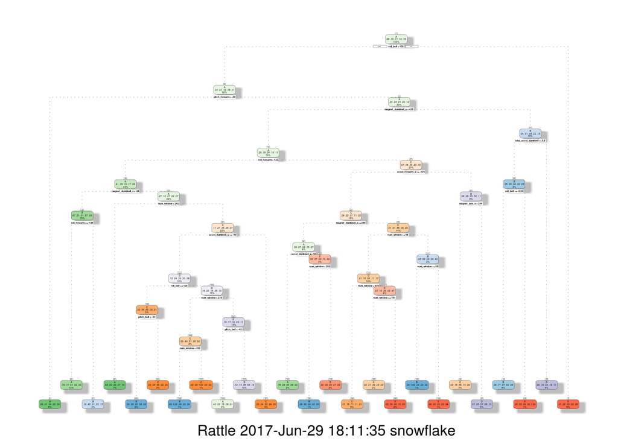

```r
set.seed(2468)
decisionTreeModel <- rpart(classe ~ ., data=Train.partition, method="class")
fancyRpartPlot(decisionTreeModel)
```

Predecting using the prevuies model

```r
predictDecisionTree <- predict(decisionTreeModel, newdata=Test.partition, type="class")
confMatDecisionTree <- confusionMatrix(predictDecisionTree, Test.partition$classe)
confMatDecisionTree
```

```
## Confusion Matrix and Statistics
##
##           Reference
## Prediction    A    B    C    D    E
##          A 1512  185   38   48   52
##          B   52  658   37   71   70
##          C   11  156  889  110   21
##          D   93  127   61  678  153
##          E    6   13    1   57  786
##
## Overall Statistics
##
##                Accuracy : 0.7686
##                  95% CI : (0.7576, 0.7793)
##     No Information Rate : 0.2845
##     P-Value [Acc > NIR] : < 2.2e-16
##
##                   Kappa : 0.7067
##  Mcnemar's Test P-Value : < 2.2e-16
##
## Statistics by Class:
##
##                      Class: A Class: B Class: C Class: D Class: E
## Sensitivity            0.9032   0.5777   0.8665   0.7033   0.7264
## Specificity            0.9233   0.9515   0.9387   0.9118   0.9840
## Pos Pred Value         0.8240   0.7410   0.7489   0.6097   0.9108
## Neg Pred Value         0.9600   0.9037   0.9708   0.9401   0.9411
## Prevalence             0.2845   0.1935   0.1743   0.1638   0.1839
## Detection Rate         0.2569   0.1118   0.1511   0.1152   0.1336
## Detection Prevalence   0.3118   0.1509   0.2017   0.1890   0.1466
## Balanced Accuracy      0.9133   0.7646   0.9026   0.8076   0.8552
```

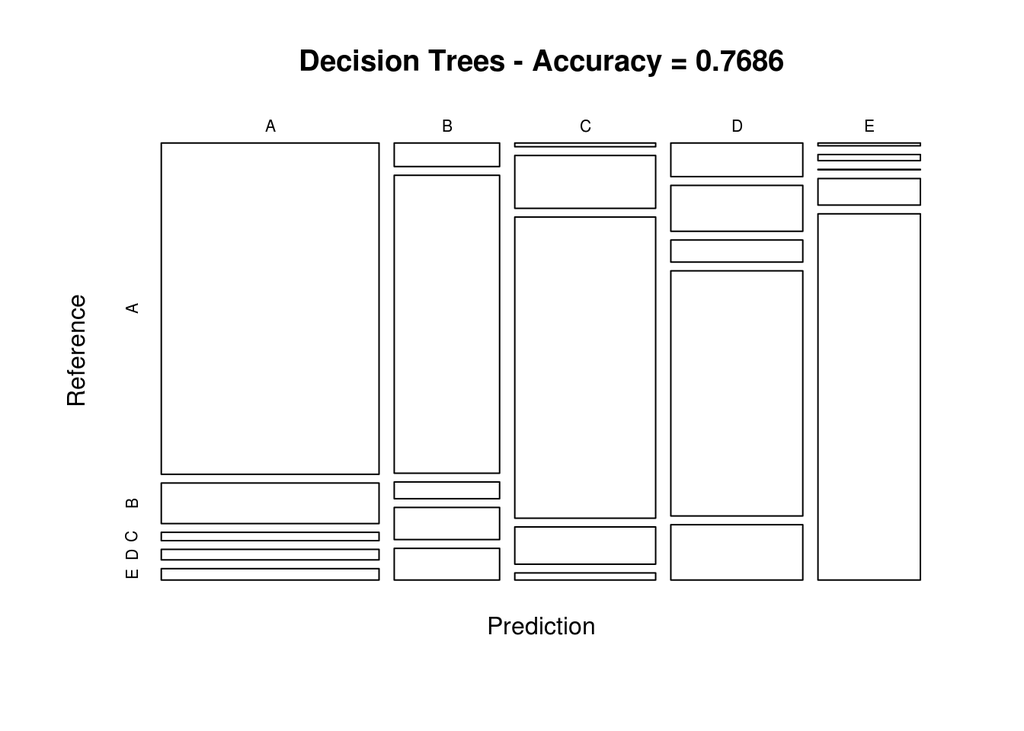

```r
# plot matrix results
plot(confMatDecisionTree$table, col = confMatDecisionTree$byClass,
     main = paste("Decision Trees - Accuracy =",
                  round(confMatDecisionTree$overall['Accuracy'], 4)))
```

# Generalized Boosted Model

Creating the Model

```r
set.seed(2468)
controlGBM <- trainControl(method = "repeatedcv", number = 5, repeats = 1)
GBM.Model  <- train(classe ~ ., data=Train.partition, method = "gbm",
                    trControl = controlGBM, verbose = FALSE)
GBM.Model$finalModel
```

```
## A gradient boosted model with multinomial loss function.
## 150 iterations were performed.
## There were 53 predictors of which 44 had non-zero influence.
```

```r
# in some cases u may get this msg andu need to accept it in order to using the gbm model
# 1 package is needed for this model and is not installed. (gbm). Would you like to try to install it now?
# 1: yes
# 2: no
```

Predecting using the prevuies model

```r
predictGBM<- predict(GBM.Model, newdata=Test.partition)
confMatGBM <- confusionMatrix(predictGBM, Test.partition$classe)
confMatGBM
```

```
## Confusion Matrix and Statistics
##
##           Reference
## Prediction    A    B    C    D    E
##          A 1672   13    0    3    0
##          B    2 1115    7    9    2
##          C    0   11 1015   20    1
##          D    0    0    3  931   10
##          E    0    0    1    1 1069
##
## Overall Statistics
##
##                Accuracy : 0.9859
##                  95% CI : (0.9825, 0.9888)
##     No Information Rate : 0.2845
##     P-Value [Acc > NIR] : < 2.2e-16
##
##                   Kappa : 0.9822
##  Mcnemar's Test P-Value : NA
##
## Statistics by Class:
##
##                      Class: A Class: B Class: C Class: D Class: E
## Sensitivity            0.9988   0.9789   0.9893   0.9658   0.9880
## Specificity            0.9962   0.9958   0.9934   0.9974   0.9996
## Pos Pred Value         0.9905   0.9824   0.9694   0.9862   0.9981
## Neg Pred Value         0.9995   0.9949   0.9977   0.9933   0.9973
## Prevalence             0.2845   0.1935   0.1743   0.1638   0.1839
## Detection Rate         0.2841   0.1895   0.1725   0.1582   0.1816
## Detection Prevalence   0.2868   0.1929   0.1779   0.1604   0.1820
## Balanced Accuracy      0.9975   0.9874   0.9913   0.9816   0.9938
```

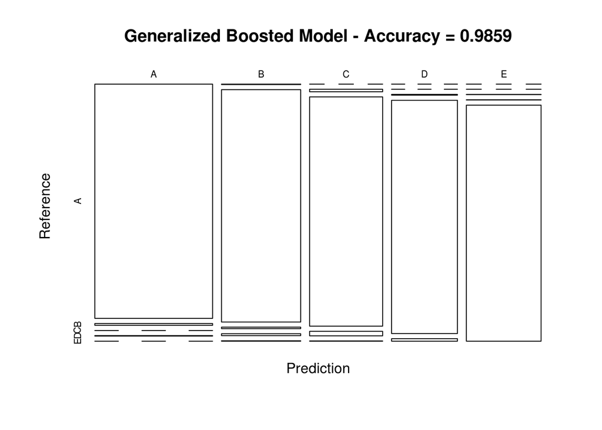

```r
# plot matrix results
plot(confMatGBM$table, col = confMatGBM$byClass,
     main = paste("Generalized Boosted Model - Accuracy =",
                  round(confMatGBM$overall['Accuracy'], 4)))
```

The accuracy of the 3 regression modeling methods above are:

Cross Validation “Random Forest” : 0.9976 Decision Tree : 0.7686 Generalized Boosted Model : 0.9859

from the showen Accuracy (Cross Validation “Random Forest”) is the best model and will used to predect the testing set.

## Applying the (Cross Validation “Random Forest”) to the testing set

```r
predictTest <- predict(RandomForestModel, newdata=testing)
predictTest
```

```
##  [1] B A B A A E D B A A B C B A E E A B B B
## Levels: A B C D E
```